# spatial data operations cheatsheet

```r
#Essentail libraries
library(sf)
library(raster)
library(dplyr)
library(spData)
library(knitr)
```

## This section provides an overview of spatial operations on vector geographic data represented as simple features in the sf packag.

## Subsetting

### In this example, We will subset Newzealnd heights which are in Canterbury only. Canterbury area is defined as a subset from another data file of Newzealnd

```r
View(nz)
kable(head(nz_height),caption = "NZ_height")
```

NZ_height

| t50_fid | elevation | geometry |
| --- | --- | --- |
| 2353944 | 2723 | c(1204142.602899, 5049971.286576) |
| 2354404 | 2820 | c(1234725.324941, 5048309.301716) |
| 2354405 | 2830 | c(1235914.510883, 5048745.117245) |
| 2369113 | 3033 | c(1259701.635366, 5076570.049236) |
| 2362630 | 2749 | c(1378169.599677, 5158491.45311) |
| 2362814 | 2822 | c(1389460.040722, 5168749.085743) |

```r
canterbury = nz %>% filter(Name == "Canterbury")
#createing an object representing Canterbury

canterbury_height = nz_height[canterbury, ]
#uses spatial subsetting to return all high points in the region

knitr::kable (canterbury_height[1:10,],caption = "canterbury_height")
```

canterbury_height

|  | t50_fid | elevation | geometry |
| --- | --- | --- | --- |
| 5 | 2362630 | 2749 | c(1378169.599677, 5158491.45311) |
| 6 | 2362814 | 2822 | c(1389460.040722, 5168749.085743) |
| 7 | 2362817 | 2778 | c(1390166.225031, 5169466.157608) |
| 8 | 2363991 | 3004 | c(1372357.036308, 5172728.742941) |
| 9 | 2363993 | 3114 | c(1372062.487198, 5173236.285371) |
| 10 | 2363994 | 2882 | c(1372810.145977, 5173419.137097) |
| 11 | 2363995 | 2796 | c(1372579.11378, 5173989.196072) |
| 13 | 2363997 | 3070 | c(1373796.364705, 5174143.63799) |
| 14 | 2363998 | 3061 | c(1373955.197775, 5174231.359663) |
| 15 | 2363999 | 3077 | c(1373984.433313, 5175228.130434) |

```r
#presenting ten rows
```

### Visualization output for hights in Canterbury only

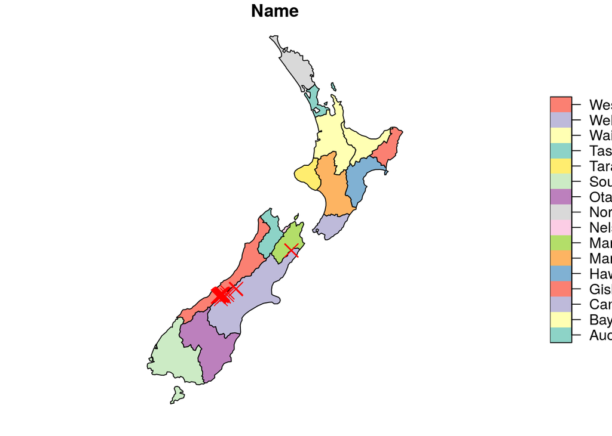

```r
plot(nz["Name"], reset = FALSE)
plot(canterbury_height, add = TRUE, col = "red", pch = 4 , cex = 2  , border= "black")
```

```r
?plot
```

```
## Help on topic 'plot' was found in the following packages:
##
##   Package               Library
##   raster                /home/sherif/R/x86_64-pc-linux-gnu-library/3.4
##   sf                    /home/sherif/R/x86_64-pc-linux-gnu-library/3.4
##   graphics              /usr/lib/R/library
##
##
## Using the first match ...
```

## Describing spatial relationships between objects

### First will create 3 different objects to play with

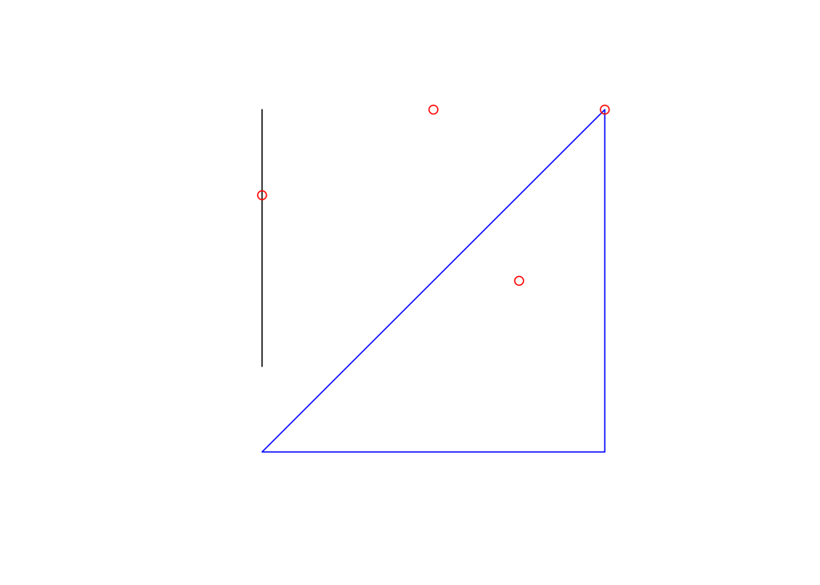

```r
# create a polygon
a_poly = st_polygon(list(rbind(c(-1, -1), c(1, -1), c(1, 1), c(-1, -1))))
a = st_sfc(a_poly)

# create a line
l_line = st_linestring(x = matrix(c(-1, -1, -0.5, 1), ncol = 2))
l = st_sfc(l_line)

# create points
p_matrix = matrix(c(0.5, 1, -1, 0, 0, 1, 0.5, 1), ncol = 2)
p_multi = st_multipoint(x = p_matrix)
p = st_cast(st_sfc(p_multi), "POINT")

plot(a,border = "blue")
plot(l,add=TRUE)
plot(p ,add = TRUE,col = "red")
```

###Is there an intersection using st_intersects function

```r
##Is there an intersection between the polygon and the points?
st_intersects(p, a, sparse = FALSE)
```

```
##       [,1]
## [1,]  TRUE
## [2,]  TRUE
## [3,] FALSE
## [4,] FALSE
```

### Is there points which do not intersect using st_disjoint()

```r
st_disjoint(p, a, sparse = FALSE)[, 1]
```

```
## [1] FALSE FALSE  TRUE  TRUE
```

```r
#note [, 1] converts the result into a vector
```

### Are some objects completely within another object using st_within()

```r
st_within(p, a, sparse = FALSE)[, 1]
```

```
## [1]  TRUE FALSE FALSE FALSE
```

```r
#This applies only to the first object, as the other one which used to bet TRUE is only touching the polygon's border
```

### Which points touch the border using st_touchs()

```r
st_touches(p, a, sparse = FALSE)[, 1]
```

```
## [1] FALSE  TRUE FALSE FALSE
```

### Which objects are within specific distance from another object using st_is_within_distance

```r
st_is_within_distance(p, a, dist = 0.9, sparse= FALSE)
```

```
##       [,1]
## [1,]  TRUE
## [2,]  TRUE
## [3,] FALSE
## [4,]  TRUE
```

```r
#dist : distance threshold; geometry indexes with distances smaller or equal to this value are returned
```

## Spatial joining

#### Spatial data joining relies on shared areas of geographic space

### In the next example. We will create ten points randomly distributed across the Earth’s surface. Of the points that are on land, which countries are they in? using st_join

```r
##Creating data frame of random ten points
set.seed(2018) # set seed for reproducibility
(bb_world = st_bbox(world)) # the world's bounds
```

```
##       xmin       ymin       xmax       ymax
## -180.00000  -90.00000  180.00000   83.64513
```

```
#>   xmin   ymin   xmax   ymax
#> -180.0  -90.0  180.0   83.6
```

```r
random_df = tibble(
  x = runif(n = 10, min = bb_world[1], max = bb_world[3]),
  y = runif(n = 10, min = bb_world[2], max = bb_world[4])
)
random_points = random_df %>%
  st_as_sf(coords = c("x", "y")) %>% # set coordinates
  st_set_crs(4326) # set geographic CRS
class(random_points)
```

```
## [1] "sf"         "data.frame"
```

```r
#By default, st_join() performs a left join (see section 3.2.3), but it can also do inner joins by setting the argument left = FALSE

world$name_long = as.character(world$name_long)

world_random = world[random_points, ]
```

```
## although coordinates are longitude/latitude, st_intersects assumes that they are planar
```

```r
#subseting the points from world data to add different attributes to it

#View(world_random)
random_joined = st_join(world_random, world["name_long"])
```

```
## although coordinates are longitude/latitude, st_intersects assumes that they are planar
```

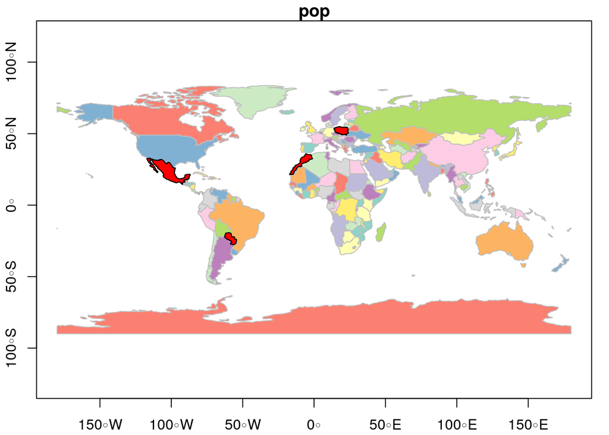

```r
#View(random_joined)

plot(world["pop"], col = sf.colors(12, categorical = TRUE), border = 'grey',
     axes = TRUE, reset = FALSE)
plot(random_joined,pch = 3, add = TRUE, col = "red")
```

###Only four points are on the land, They locate in Mexico, Morroco, Poland and Paraguay.

## Non-overlapping joins within distance

### In this example, two geographic datasets do not touch but still have a strong geographic relationship enabling joins. The datasets cycle_hire and cycle_hire_osm, already attached in the spData package.

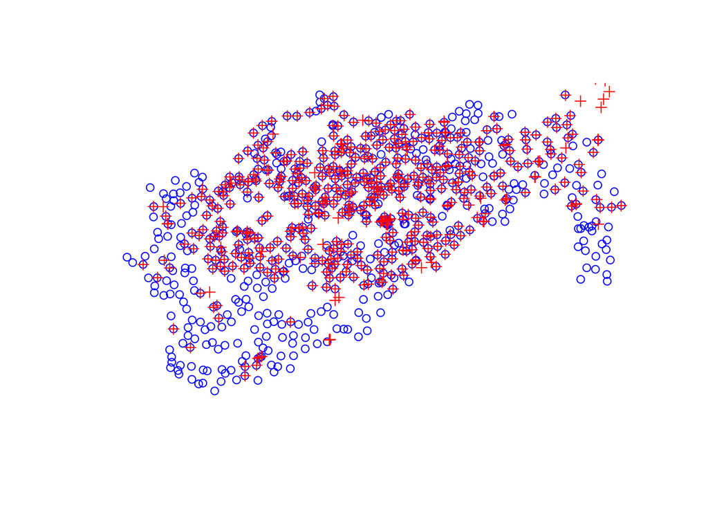

```r
plot(st_geometry(cycle_hire), col = "blue")
plot(st_geometry(cycle_hire_osm), add = TRUE, pch = 3, col = "red")
```

###Check if any points are in touch

```r
any(st_touches(cycle_hire, cycle_hire_osm, sparse = FALSE))
```

```
## although coordinates are longitude/latitude, st_touches assumes that they are planar
```

```
## [1] FALSE
```

### Specifcying which points withing specific distance of each others

```r
cycle_hire_P = st_transform(cycle_hire, 27700)
cycle_hire_osm_P = st_transform(cycle_hire_osm, 27700)
sel = st_is_within_distance(cycle_hire_P, cycle_hire_osm_P, dist = 20)
View(sel)
summary(lengths(sel) > 0)
```

```
##    Mode   FALSE    TRUE
## logical     304     438
```

### This shows that there are 438 points in the target object cycle_hire_P within the threshold distance of cycle_hire_osm_P

```r
#Jioing the two datasets
z = st_join(cycle_hire_P, cycle_hire_osm_P, st_is_within_distance, dist = 20)
nrow(cycle_hire_P)
```

```
## [1] 742
```

```
#> [1] 742
```

```r
nrow(z)
```

```
## [1] 762
```

```
#> [1] 762
```

```r
View(z)
```

### Note that the number of rows in the joined result is greater than the original file. This is because some cycle hire stations in cycle_hire_P have multiple matches in cycle_hire_osm_P

```r
#check duplicates ID
n_occur <- data.frame(table(z$id))
#gives you a data frame with a list of ids and the number of times they occurred.

n_occur[n_occur$Freq > 1,]
```

```
##     Var1 Freq
## 131  134    2
## 246  253    2
## 459  482    4
## 461  484    8
## 484  510    6
## 580  613    4
```

```r
#What are The duplicates IDs
```

### The solution to the duplicates. Assuming that we care about the capacity variable we can aggregate Id variable and get the mean in term of capacity variable

```r
z = z %>%
  group_by(id) %>%
  summarize(capacity = mean(capacity))
nrow(z) == nrow(cycle_hire)
```

```
## [1] TRUE
```

## Alternatively removing duplicates rows in term of Id

```r
z1 = z %>% distinct(id, .keep_all = TRUE)
nrow(z1) == nrow(cycle_hire)
```

```
## [1] TRUE
```

## The distance between two objects is calculated with the st_distance()

```r
#find the distance between the highest point in New Zealand and the geographic centroid of the Canterbury region.

nz_heighest = nz_height %>% top_n(n = 1, wt = elevation)
canterbury_centroid = st_centroid(canterbury)
st_distance(nz_heighest, canterbury_centroid)
```

```
## Units: [m]
##        [,1]
## [1,] 115540
```